# IODS course project

Atte Koskivaara

# Introduction to Open Data Science - Course Project

# About the project

```r
# This is a so-called "R chunk" where you can write R code.

date()
```

```
## [1] "Mon Dec 12 14:27:16 2022"
```

I’m **excited** about the course. Open data science is an important part of academic research and therefore I wish to learn tools related to it.

**Exercise set 1:** With some earlier experience from R, this was an excellent reminder exercise. And there was also some new things as well - for example the flexible use of *mutate()*, *group_by()* and *summarise()* seems handy.

My repository: https://github.com/attekoskivaara/IODS-project

# Regression modelling and analysis

This week included regression analysis and data wrangling.

- No major issues with **exercise 2** and **data wrangling**, however those tasks and codes helped a lot.
- Git tab disappeared from my Rstudio all of a sudden. Therefore I started to update github using GitBash.

```r
date()
```

```
## [1] "Mon Dec 12 14:27:16 2022"
```

#### 1) Load and inspect dataset

```r
## Analysis ##
# load dataset
library(tidyverse)
loaded <- read_csv("Learning2014.csv")
# Inspect the datase & check data table
loaded
```

```
## # A tibble: 166 x 7
##    gender   Age Attitude  deep  stra  surf Points
##    <chr>  <dbl>    <dbl> <dbl> <dbl> <dbl>  <dbl>
##  1 F         53       37  3.58  3.38  2.58     25
##  2 M         55       31  2.92  2.75  3.17     12
##  3 F         49       25  3.5   3.62  2.25     24
##  4 M         53       35  3.5   3.12  2.25     10
##  5 M         49       37  3.67  3.62  2.83     22
##  6 F         38       38  4.75  3.62  2.42     21
##  7 M         50       35  3.83  2.25  1.92     21
##  8 F         37       29  3.25  4     2.83     31
##  9 M         37       38  4.33  4.25  2.17     24
## 10 F         42       21  4     3.5   3        26
## # ... with 156 more rows
```

```r
dim(loaded)
```

```
## [1] 166   7
```

```r
str(loaded)
```

```
## spc_tbl_ [166 x 7] (S3: spec_tbl_df/tbl_df/tbl/data.frame)
##  $ gender  : chr [1:166] "F" "M" "F" "M" ...
##  $ Age     : num [1:166] 53 55 49 53 49 38 50 37 37 42 ...
##  $ Attitude: num [1:166] 37 31 25 35 37 38 35 29 38 21 ...
##  $ deep    : num [1:166] 3.58 2.92 3.5 3.5 3.67 ...
##  $ stra    : num [1:166] 3.38 2.75 3.62 3.12 3.62 ...
##  $ surf    : num [1:166] 2.58 3.17 2.25 2.25 2.83 ...
##  $ Points  : num [1:166] 25 12 24 10 22 21 21 31 24 26 ...
##  - attr(*, "spec")=
##   .. cols(
##   ..   gender = col_character(),
##   ..   Age = col_double(),
##   ..   Attitude = col_double(),
##   ..   deep = col_double(),
##   ..   stra = col_double(),
##   ..   surf = col_double(),
##   ..   Points = col_double()
##   .. )
##  - attr(*, "problems")=<externalptr>
```

- The dataset dimensions: 166x7
- This means that there are 7 variables, from which variable gender is categorical and others are numerical
- Columns stra, surf and deep are calculated means from questions regarding that topic
- Age column reveals the age of a person. Min age is 17 and max is 55.
- Attitude column is persons attitude toward statistics
- Points column is Exam points (in the course where the questionnaire was implemented)

#### 2) Summary of variables and plot matrix

```r
# Summary of variables
library(GGally)
```

```r
library(ggplot2)

# summary of variable data
summary(loaded)
```

```
##     gender               Age           Attitude          deep
##  Length:166         Min.   :17.00   Min.   :14.00   Min.   :1.583
##  Class :character   1st Qu.:21.00   1st Qu.:26.00   1st Qu.:3.333
##  Mode  :character   Median :22.00   Median :32.00   Median :3.667
##                     Mean   :25.51   Mean   :31.43   Mean   :3.680
##                     3rd Qu.:27.00   3rd Qu.:37.00   3rd Qu.:4.083
##                     Max.   :55.00   Max.   :50.00   Max.   :4.917
##       stra            surf           Points
##  Min.   :1.250   Min.   :1.583   Min.   : 7.00
##  1st Qu.:2.625   1st Qu.:2.417   1st Qu.:19.00
##  Median :3.188   Median :2.833   Median :23.00
##  Mean   :3.121   Mean   :2.787   Mean   :22.72
##  3rd Qu.:3.625   3rd Qu.:3.167   3rd Qu.:27.75
##  Max.   :5.000   Max.   :4.333   Max.   :33.00
```

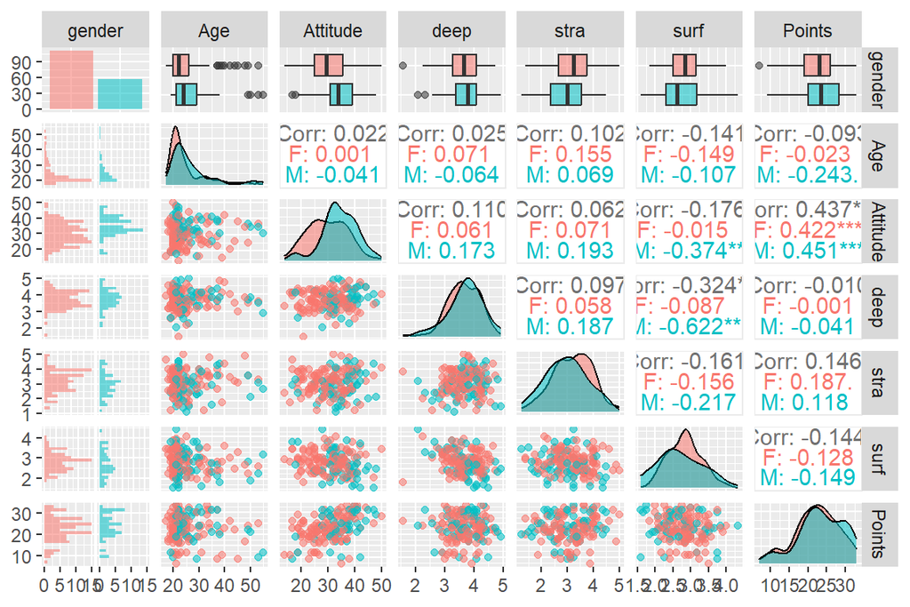

```r
# plot matrix
p <- ggpairs(loaded, mapping = aes(col = gender, alpha = 0.3),
              lower = list(combo = wrap("facethist", bins = 20)))
p
```

- Distribution of Age variable is skewed toward younger persons.
- Attitude scores seems to have statistical significance and correlated with Points variable.

#### 3) Regression modelling

```r
# Regression model
my_model <- lm(Points ~ Attitude + stra + surf, data = loaded)
summary(my_model)
```

```
##
## Call:
## lm(formula = Points ~ Attitude + stra + surf, data = loaded)
##
## Residuals:
##      Min       1Q   Median       3Q      Max
## -17.1550  -3.4346   0.5156   3.6401  10.8952
##
## Coefficients:
##             Estimate Std. Error t value Pr(>|t|)
## (Intercept) 11.01711    3.68375   2.991  0.00322 **
## Attitude     0.33952    0.05741   5.913 1.93e-08 ***
## stra         0.85313    0.54159   1.575  0.11716
## surf        -0.58607    0.80138  -0.731  0.46563
## ---
## Signif. codes:  0 '***' 0.001 '**' 0.01 '*' 0.05 '.' 0.1 ' ' 1
##
## Residual standard error: 5.296 on 162 degrees of freedom
## Multiple R-squared:  0.2074, Adjusted R-squared:  0.1927
## F-statistic: 14.13 on 3 and 162 DF,  p-value: 3.156e-08
```